# GP_Evaluation3

Yuanxi Cheng

2022-09-09

## Evaluation of Boys, Girls, and Total Player Population Vs Golf Courses Per State

### Map of Golf Courses in Each State

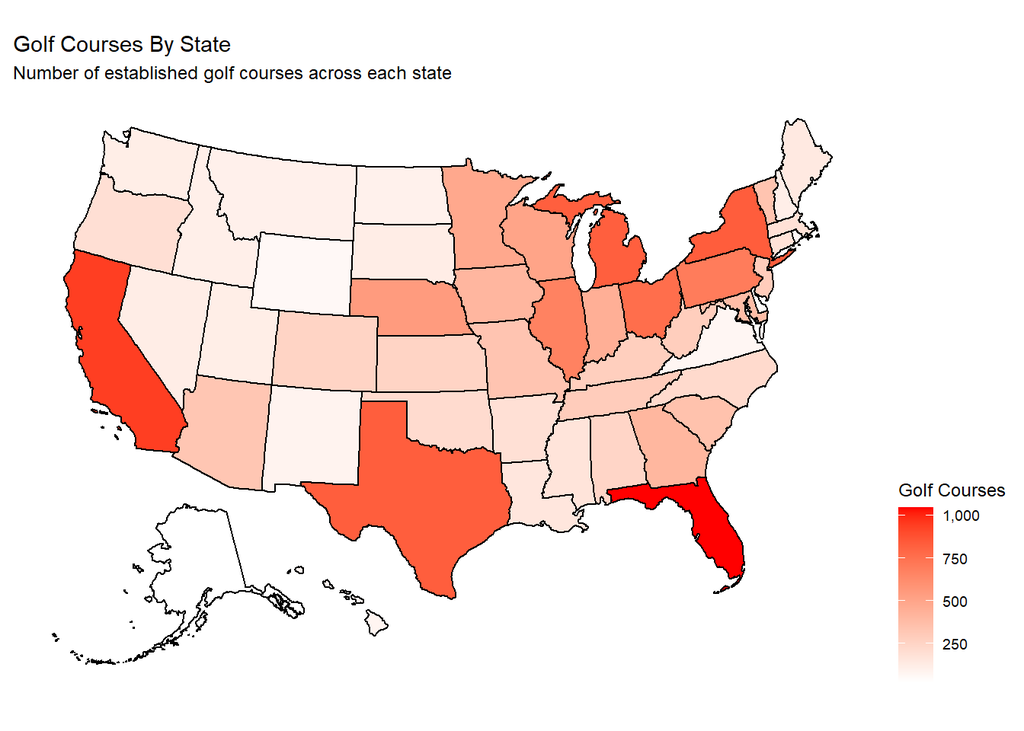

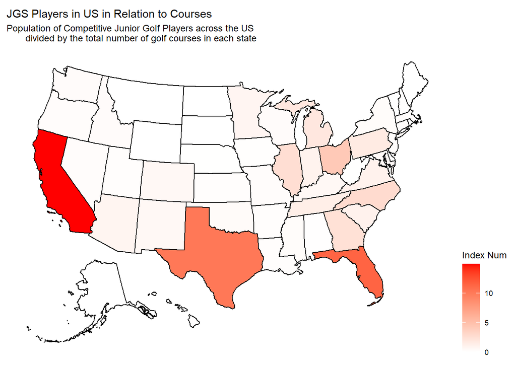

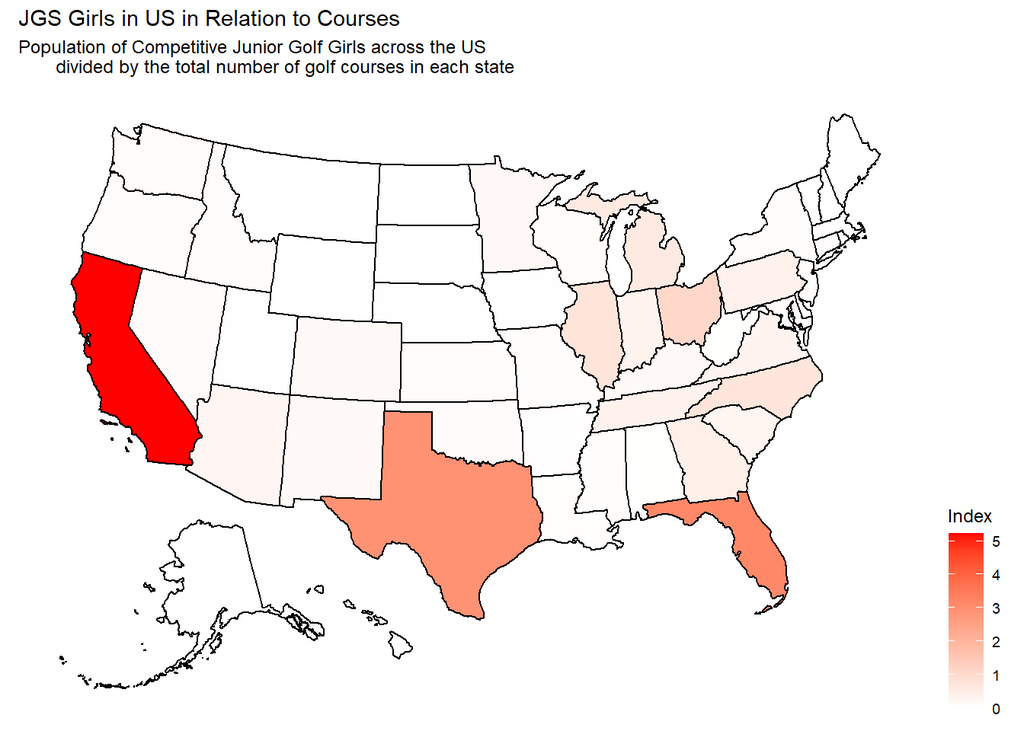

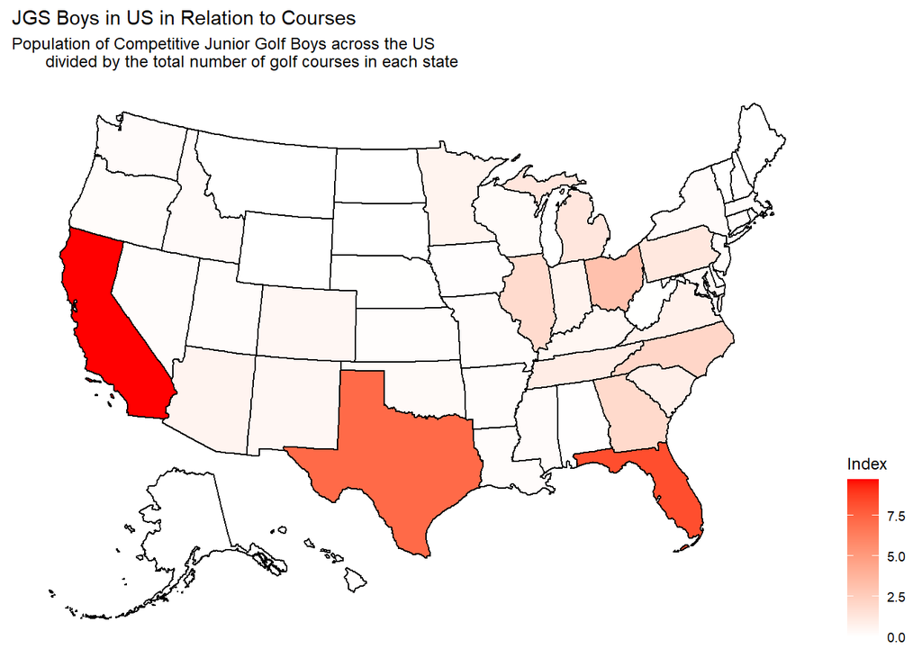

## Scatter Plots

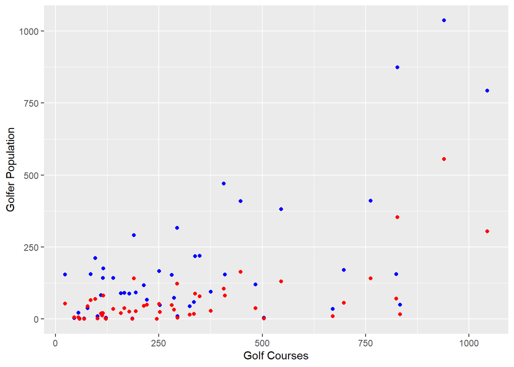

### Fitting Linear Models (Not Standardized Population)

### Boys:

#### Linear Regression Line

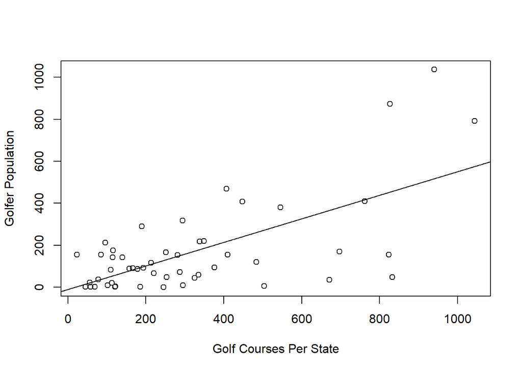

#### Analyzing Residuals and Testing Regression:

```
##
## Call:
## lm(formula = y ~ x, data = boysVsCourses)
##
## Residuals:
##     Min      1Q  Median      3Q     Max
## -407.68  -82.77   -4.42   81.87  520.47
##
## Coefficients:
##             Estimate Std. Error t value Pr(>|t|)
## (Intercept) -9.24814   38.13116  -0.243    0.809
## x            0.55933    0.09292   6.020 2.34e-07 ***
## ---
## Signif. codes:  0 '***' 0.001 '**' 0.01 '*' 0.05 '.' 0.1 ' ' 1
##
## Residual standard error: 169.1 on 48 degrees of freedom
## Multiple R-squared:  0.4302, Adjusted R-squared:  0.4183
## F-statistic: 36.24 on 1 and 48 DF,  p-value: 2.34e-07
```

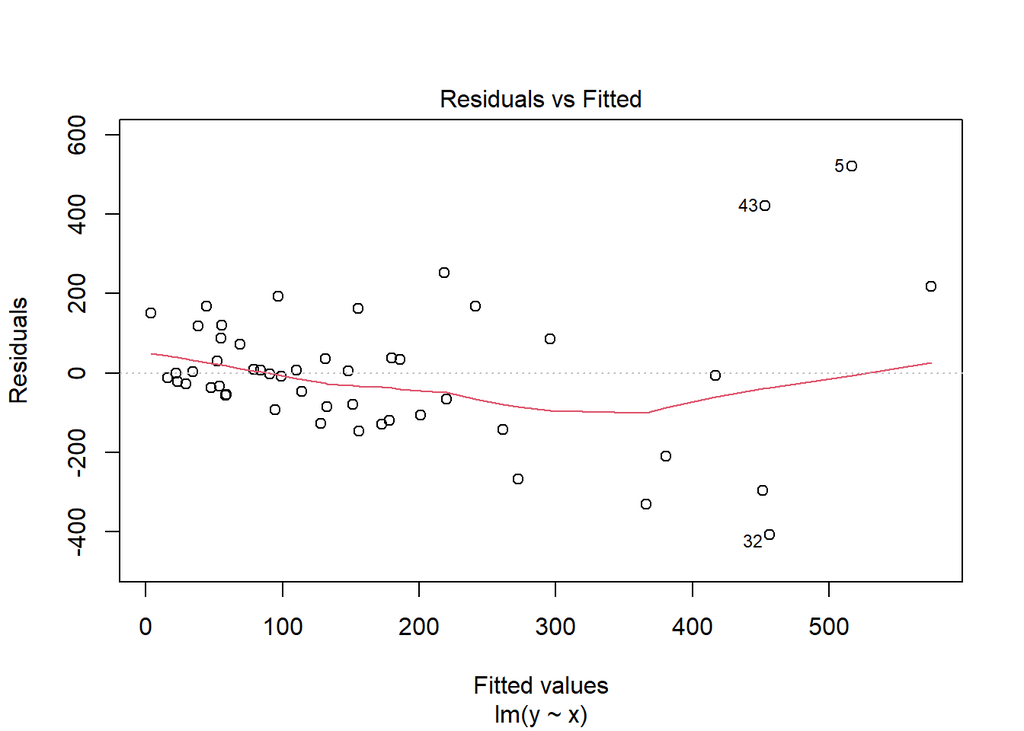

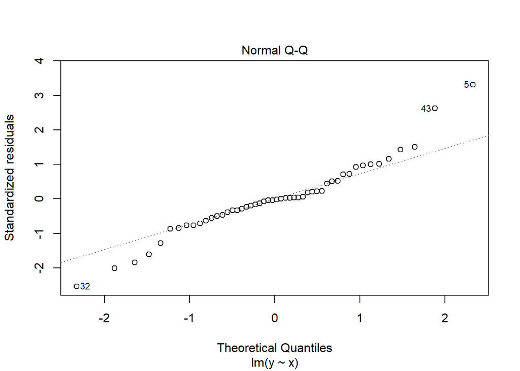

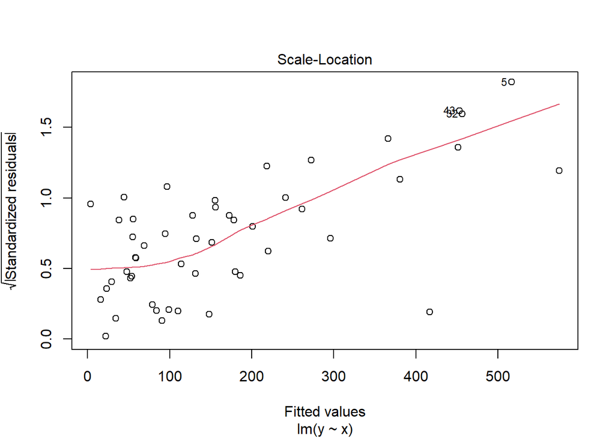

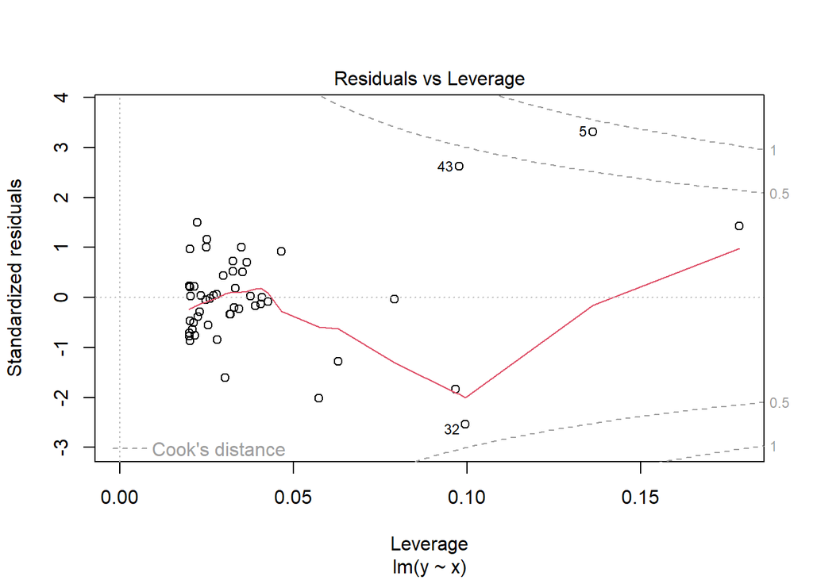

### Girls:

#### Linear Regression Line

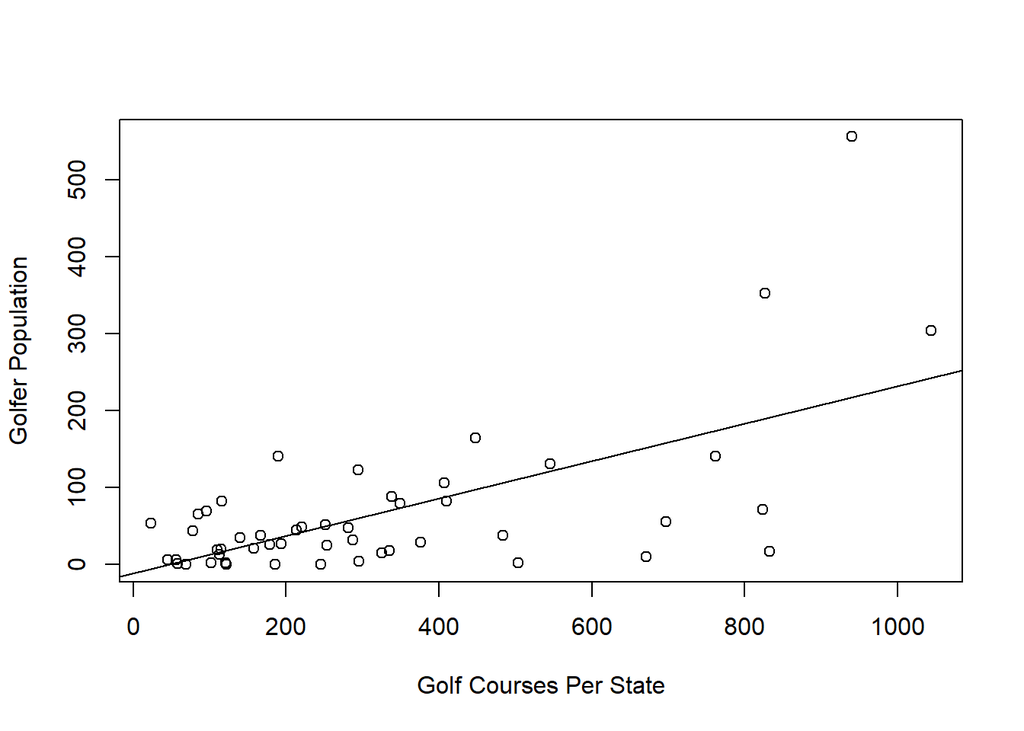

#### Analyzing Residuals and Testing Regression Girls:

```
##
## Call:
## lm(formula = y ~ x, data = girlsVsCourses)
##
## Residuals:
##     Min      1Q  Median      3Q     Max
## -173.93  -31.08   -2.30   16.13  339.07
##
## Coefficients:
##              Estimate Std. Error t value Pr(>|t|)
## (Intercept) -11.48010   17.56691  -0.654    0.517
## x             0.24299    0.04281   5.676 7.79e-07 ***
## ---
## Signif. codes:  0 '***' 0.001 '**' 0.01 '*' 0.05 '.' 0.1 ' ' 1
##
## Residual standard error: 77.89 on 48 degrees of freedom
## Multiple R-squared:  0.4017, Adjusted R-squared:  0.3892
## F-statistic: 32.22 on 1 and 48 DF,  p-value: 7.794e-07
```

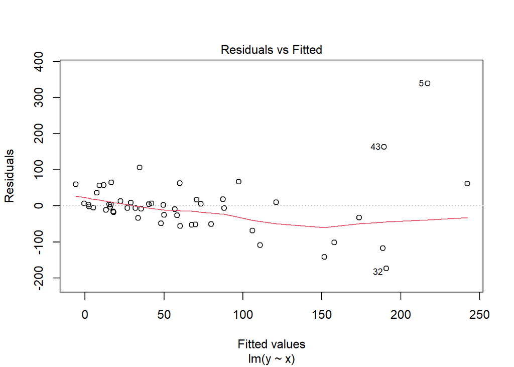

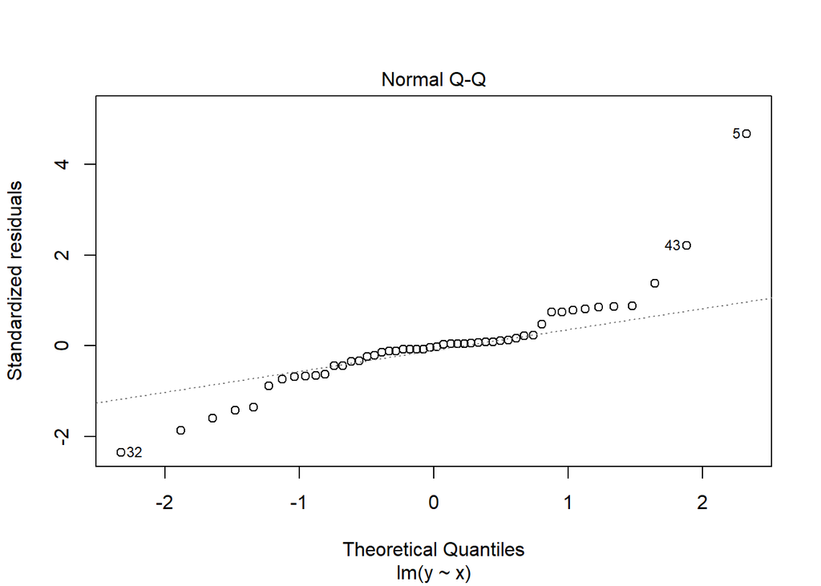

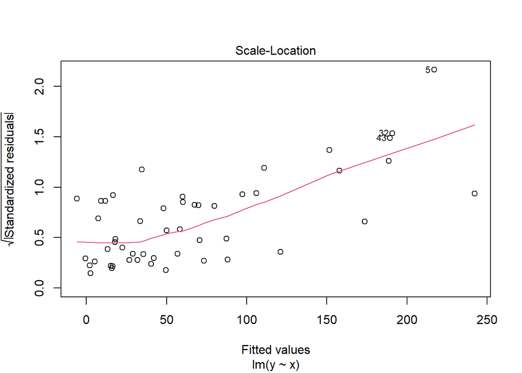

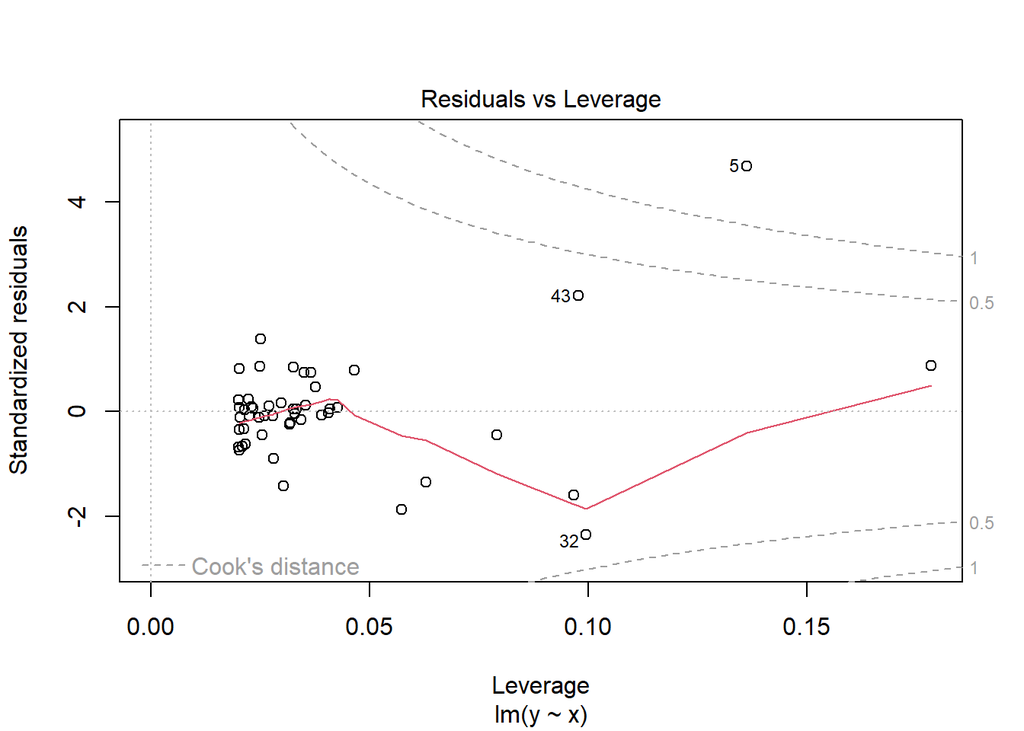

### Linear Modeling Results - Positive

#### Based on how far we analyzed the reisuals and regression line, we can say that the number of golf courses open to play in each state is a significant factor that affects golf popularity within that area. The linear regression model seems to be a working fit, but looking at the scatterplot also gives an impression that an exponential regression model might be able to fit the data better. Ultimately, we are still able to conclude that as the number of golf courses increase within an area, so will the number of players.